# Coursera Reproducible Research Course Project 2: Severe Weather Events

J Cecire

9/11/2021

## Synopsis

This project investigates the severe weather events in the US based on the U.S. National Oceanic and Atmospheric Administration’s (NOAA) storm database. This database tracks characteristics of major storms and weather events in the United States, including when and where they occur, as well as estimates of any fatalities, injuries, and property damage. (For a detailled description of the NOAA storm database see: https://www.ncdc.noaa.gov/stormevents/) Using the NOAA storm database this analysis clearly shows that tornados have the most harmful impact on people’s health as they resulted in the highest number of fatalities and injures. This analysis also revealed that floods caused the most property damage in terms of price and droughts caused the crop damage in terms of price.

## Questions

1. Across the United States, which types of events (as indicated in the EVTYPE variable) are most harmful with respect to population health?
2. Across the United States, which types of events have the greatest economic consequences?

## Loading Packages

```r
library(dplyr)
library(knitr)
```

## Loading Data

```r
stormData <- read.csv("./repdata-data-StormData.csv.bz2")
summary(stormData)
```

```
##     STATE__                  BGN_DATE             BGN_TIME
##  Min.   : 1.0   5/25/2011 0:00:00:  1202   12:00:00 AM: 10163
##  1st Qu.:19.0   4/27/2011 0:00:00:  1193   06:00:00 PM:  7350
##  Median :30.0   6/9/2011 0:00:00 :  1030   04:00:00 PM:  7261
##  Mean   :31.2   5/30/2004 0:00:00:  1016   05:00:00 PM:  6891
##  3rd Qu.:45.0   4/4/2011 0:00:00 :  1009   12:00:00 PM:  6703
##  Max.   :95.0   4/2/2006 0:00:00 :   981   03:00:00 PM:  6700
##                 (Other)          :895866   (Other)    :857229
##    TIME_ZONE          COUNTY           COUNTYNAME         STATE
##  CST    :547493   Min.   :  0.0   JEFFERSON :  7840   TX     : 83728
##  EST    :245558   1st Qu.: 31.0   WASHINGTON:  7603   KS     : 53440
##  MST    : 68390   Median : 75.0   JACKSON   :  6660   OK     : 46802
##  PST    : 28302   Mean   :100.6   FRANKLIN  :  6256   MO     : 35648
##  AST    :  6360   3rd Qu.:131.0   LINCOLN   :  5937   IA     : 31069
##  HST    :  2563   Max.   :873.0   MADISON   :  5632   NE     : 30271
##  (Other):  3631                   (Other)   :862369   (Other):621339
##                EVTYPE         BGN_RANGE           BGN_AZI
##  HAIL             :288661   Min.   :   0.000          :547332
##  TSTM WIND        :219940   1st Qu.:   0.000   N      : 86752
##  THUNDERSTORM WIND: 82563   Median :   0.000   W      : 38446
##  TORNADO          : 60652   Mean   :   1.484   S      : 37558
##  FLASH FLOOD      : 54277   3rd Qu.:   1.000   E      : 33178
##  FLOOD            : 25326   Max.   :3749.000   NW     : 24041
##  (Other)          :170878                      (Other):134990
##          BGN_LOCATI                  END_DATE             END_TIME
##               :287743                    :243411              :238978
##  COUNTYWIDE   : 19680   4/27/2011 0:00:00:  1214   06:00:00 PM:  9802
##  Countywide   :   993   5/25/2011 0:00:00:  1196   05:00:00 PM:  8314
##  SPRINGFIELD  :   843   6/9/2011 0:00:00 :  1021   04:00:00 PM:  8104
##  SOUTH PORTION:   810   4/4/2011 0:00:00 :  1007   12:00:00 PM:  7483
##  NORTH PORTION:   784   5/30/2004 0:00:00:   998   11:59:00 PM:  7184
##  (Other)      :591444   (Other)          :653450   (Other)    :622432
##    COUNTY_END COUNTYENDN       END_RANGE           END_AZI
##  Min.   :0    Mode:logical   Min.   :  0.0000          :724837
##  1st Qu.:0    NA's:902297    1st Qu.:  0.0000   N      : 28082
##  Median :0                   Median :  0.0000   S      : 22510
##  Mean   :0                   Mean   :  0.9862   W      : 20119
##  3rd Qu.:0                   3rd Qu.:  0.0000   E      : 20047
##  Max.   :0                   Max.   :925.0000   NE     : 14606
##                                                 (Other): 72096
```

[output cut: 41 more lines]

```
##  Min.   :   0   Min.   :-14451   Min.   :   0   Min.   :-14455
##  1st Qu.:2802   1st Qu.:  7247   1st Qu.:   0   1st Qu.:     0
##  Median :3540   Median :  8707   Median :   0   Median :     0
##  Mean   :2875   Mean   :  6940   Mean   :1452   Mean   :  3509
##  3rd Qu.:4019   3rd Qu.:  9605   3rd Qu.:3549   3rd Qu.:  8735
##  Max.   :9706   Max.   : 17124   Max.   :9706   Max.   :106220
##  NA's   :47                      NA's   :40
##                                            REMARKS           REFNUM
##                                                :287433   Min.   :     1
##                                                : 24013   1st Qu.:225575
##  Trees down.\n                                 :  1110   Median :451149
##  Several trees were blown down.\n              :   568   Mean   :451149
##  Trees were downed.\n                          :   446   3rd Qu.:676723
##  Large trees and power lines were blown down.\n:   432   Max.   :902297
##  (Other)                                       :588295
```

```r
names(stormData)
```

```
##  [1] "STATE__"    "BGN_DATE"   "BGN_TIME"   "TIME_ZONE"  "COUNTY"
##  [6] "COUNTYNAME" "STATE"      "EVTYPE"     "BGN_RANGE"  "BGN_AZI"
## [11] "BGN_LOCATI" "END_DATE"   "END_TIME"   "COUNTY_END" "COUNTYENDN"
## [16] "END_RANGE"  "END_AZI"    "END_LOCATI" "LENGTH"     "WIDTH"
## [21] "F"          "MAG"        "FATALITIES" "INJURIES"   "PROPDMG"
## [26] "PROPDMGEXP" "CROPDMG"    "CROPDMGEXP" "WFO"        "STATEOFFIC"
## [31] "ZONENAMES"  "LATITUDE"   "LONGITUDE"  "LATITUDE_E" "LONGITUDE_"
## [36] "REMARKS"    "REFNUM"
```

```r
str(stormData)
```

```
## 'data.frame':    902297 obs. of  37 variables:
##  $ STATE__   : num  1 1 1 1 1 1 1 1 1 1 ...
##  $ BGN_DATE  : Factor w/ 16335 levels "1/1/1966 0:00:00",..: 6523 6523 4242 11116 2224 2224 2260 383 3980 3980 ...
##  $ BGN_TIME  : Factor w/ 3608 levels "00:00:00 AM",..: 272 287 2705 1683 2584 3186 242 1683 3186 3186 ...
##  $ TIME_ZONE : Factor w/ 22 levels "ADT","AKS","AST",..: 7 7 7 7 7 7 7 7 7 7 ...
##  $ COUNTY    : num  97 3 57 89 43 77 9 123 125 57 ...
##  $ COUNTYNAME: Factor w/ 29601 levels "","5NM E OF MACKINAC BRIDGE TO PRESQUE ISLE LT MI",..: 13513 1873 4598 10592 4372 10094 1973 23873 24418 4598 ...
##  $ STATE     : Factor w/ 72 levels "AK","AL","AM",..: 2 2 2 2 2 2 2 2 2 2 ...
##  $ EVTYPE    : Factor w/ 985 levels "   HIGH SURF ADVISORY",..: 834 834 834 834 834 834 834 834 834 834 ...
##  $ BGN_RANGE : num  0 0 0 0 0 0 0 0 0 0 ...
##  $ BGN_AZI   : Factor w/ 35 levels "","  N"," NW",..: 1 1 1 1 1 1 1 1 1 1 ...
##  $ BGN_LOCATI: Factor w/ 54429 levels ""," Christiansburg",..: 1 1 1 1 1 1 1 1 1 1 ...
##  $ END_DATE  : Factor w/ 6663 levels "","1/1/1993 0:00:00",..: 1 1 1 1 1 1 1 1 1 1 ...
##  $ END_TIME  : Factor w/ 3647 levels ""," 0900CST",..: 1 1 1 1 1 1 1 1 1 1 ...
##  $ COUNTY_END: num  0 0 0 0 0 0 0 0 0 0 ...
```

[output cut: 23 more lines]

## Wranggling Data

### Extracting needed Variables

Since for the rest of this analysis we will only be focusing on events that either harm the populations health or impact the economy we can wrangle and consolodate the data getting rid of unnecessary columns. The columns we will focus on are as follows:

EVTYPE: Event Type (Tornados, Flood, ….)

FATALITIES: Number of Fatalities

INJURIES: Number of Injuries

PROPDMG: Property Damage

PROPDMGEXP: Units for Property Damage (magnitudes - K,M,B)

CROPDMG: Crop Damage

CROPDMGEXP: Units for Crop Damage (magnitudes - K,M,B)

```r
keyVars <- c("EVTYPE", "FATALITIES", "INJURIES", "PROPDMG", "PROPDMGEXP", "CROPDMG", "CROPDMGEXP")
storm <- stormData[keyVars]
dim(storm)
```

```
## [1] 902297      7
```

```r
names(storm)
```

```
## [1] "EVTYPE"     "FATALITIES" "INJURIES"   "PROPDMG"    "PROPDMGEXP"
## [6] "CROPDMG"    "CROPDMGEXP"
```

```r
summary(storm)
```

```
##                EVTYPE         FATALITIES          INJURIES
##  HAIL             :288661   Min.   :  0.0000   Min.   :   0.0000
##  TSTM WIND        :219940   1st Qu.:  0.0000   1st Qu.:   0.0000
##  THUNDERSTORM WIND: 82563   Median :  0.0000   Median :   0.0000
##  TORNADO          : 60652   Mean   :  0.0168   Mean   :   0.1557
##  FLASH FLOOD      : 54277   3rd Qu.:  0.0000   3rd Qu.:   0.0000
##  FLOOD            : 25326   Max.   :583.0000   Max.   :1700.0000
##  (Other)          :170878
##     PROPDMG          PROPDMGEXP        CROPDMG          CROPDMGEXP
##  Min.   :   0.00          :465934   Min.   :  0.000          :618413
##  1st Qu.:   0.00   K      :424665   1st Qu.:  0.000   K      :281832
##  Median :   0.00   M      : 11330   Median :  0.000   M      :  1994
##  Mean   :  12.06   0      :   216   Mean   :  1.527   k      :    21
##  3rd Qu.:   0.50   B      :    40   3rd Qu.:  0.000   0      :    19
##  Max.   :5000.00   5      :    28   Max.   :990.000   B      :     9
##                    (Other):    84                     (Other):     9
```

```r
str(storm)
```

```
## 'data.frame':    902297 obs. of  7 variables:
##  $ EVTYPE    : Factor w/ 985 levels "   HIGH SURF ADVISORY",..: 834 834 834 834 834 834 834 834 834 834 ...
##  $ FATALITIES: num  0 0 0 0 0 0 0 0 1 0 ...
##  $ INJURIES  : num  15 0 2 2 2 6 1 0 14 0 ...
##  $ PROPDMG   : num  25 2.5 25 2.5 2.5 2.5 2.5 2.5 25 25 ...
##  $ PROPDMGEXP: Factor w/ 19 levels "","-","?","+",..: 17 17 17 17 17 17 17 17 17 17 ...
##  $ CROPDMG   : num  0 0 0 0 0 0 0 0 0 0 ...
##  $ CROPDMGEXP: Factor w/ 9 levels "","?","0","2",..: 1 1 1 1 1 1 1 1 1 1 ...
```

### Making the PROPDMGEXP and CROPDMGEXP columns cleaner so they can be used to calculate property and crop cost.

- Using this document (https://d396qusza40orc.cloudfront.net/repdata%2Fpeer2_doc%2Fpd01016005curr.pdf) we can tell what each unique value stands for in the PROPDMGEXP and CROPDMGEXP columns and how they relate to the PROPDMG and CROPDMG variables. So, we must first recode the information in columns PROPDMGEXP and CROPDMGEXP and then refactor them.

```r
unique(storm$PROPDMGEXP)
```

```
##  [1] K M   B m + 0 5 6 ? 4 2 3 h 7 H - 1 8
## Levels:  - ? + 0 1 2 3 4 5 6 7 8 B h H K m M
```

- Recoding and refactoring of variable PROPDMGEXP

```r
storm$PROPDMGEXP <- recode(storm$PROPDMGEXP,
                              "K" = 10^3, "M" = 10^6, " " = 1, "B" = 10^9, "m" =10^6, "+" = 0, '0' = 1, '5' = 10^5, '6' =10^6, "?" = 0, '4' = 10^4, '2' = 10^2, '3' = 10^3, "h" = 10^2, '7' = 10^7, "H" = 10^2, "-" = 0, '1' = 10, '8' = 10^8)

storm$PROPDMGEXP <- as.numeric(as.character(storm$PROPDMGEXP))
storm$PROPDMGTOTAL <- (storm$PROPDMG * storm$PROPDMGEXP)/1000000000
```

```r
unique(storm$CROPDMGEXP)
```

```
## [1]   M K m B ? 0 k 2
## Levels:  ? 0 2 B k K m M
```

- Recoding and refactoring of variable CROPDMGEXP

```r
storm$CROPDMGEXP <- recode(storm$CROPDMGEXP,
                              " " = 1,"M" = 10^6, "K" = 10^3, "m" = 10^6, "B" = 10^9, "?" = 0, "0" = 1, "k" = 10^3,"2" = 10^2)

storm$CROPDMGEXP <- as.numeric(as.character(storm$CROPDMGEXP))
storm$CROPDMGTOTAL <- (storm$CROPDMG * storm$CROPDMGEXP)/1000000000
```

## Which type of events are most harmful to human health?

- Since there are 985 different event types we are only going to look at the top 10 most fatal events and top 10 injury events.

### Fatalities

```r
stormFatalities <- aggregate(FATALITIES ~ EVTYPE, data = storm,  FUN="sum")
dim(stormFatalities)
```

```
## [1] 985   2
```

```r
names(stormFatalities)
```

```
## [1] "EVTYPE"     "FATALITIES"
```

```r
summary(stormFatalities)
```

```
##                    EVTYPE      FATALITIES
##     HIGH SURF ADVISORY:  1   Min.   :   0.00
##   COASTAL FLOOD       :  1   1st Qu.:   0.00
##   FLASH FLOOD         :  1   Median :   0.00
##   LIGHTNING           :  1   Mean   :  15.38
##   TSTM WIND           :  1   3rd Qu.:   0.00
##   TSTM WIND (G45)     :  1   Max.   :5633.00
##  (Other)              :979
```

```r
str(stormFatalities)
```

```
## 'data.frame':    985 obs. of  2 variables:
##  $ EVTYPE    : Factor w/ 985 levels "   HIGH SURF ADVISORY",..: 1 2 3 4 5 6 7 8 9 10 ...
##  $ FATALITIES: num  0 0 0 0 0 0 0 0 0 0 ...
```

- Ordering the top 10 Weather events by number of fatalities

```r
top10FatalEvents <- stormFatalities[order(-stormFatalities$FATALITIES), ][1:10, ]
top10FatalEvents
```

```
##             EVTYPE FATALITIES
## 834        TORNADO       5633
## 130 EXCESSIVE HEAT       1903
## 153    FLASH FLOOD        978
## 275           HEAT        937
## 464      LIGHTNING        816
## 856      TSTM WIND        504
## 170          FLOOD        470
## 585    RIP CURRENT        368
## 359      HIGH WIND        248
## 19       AVALANCHE        224
```

### Plot Fatalities

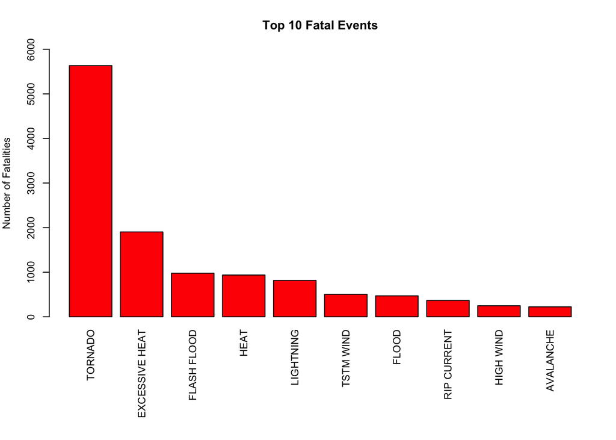

```r
par(mfrow = c(1,1), mar = c(10, 4, 4, 2), mgp = c(3, 1, 0), cex = 0.7)
barplot(top10FatalEvents$FATALITIES, names.arg = top10FatalEvents$EVTYPE, las = 3,
        main = "Top 10 Fatal Events",
        ylab = "Number of Fatalities",
        ylim = range(0,6000),
        col = c("red"))
```

### Injuries

```r
stormInjuries <- aggregate(INJURIES ~ EVTYPE, data = storm,  FUN="sum")
dim(stormInjuries)
```

```
## [1] 985   2
```

```r
names(stormInjuries)
```

```
## [1] "EVTYPE"   "INJURIES"
```

```r
summary(stormInjuries)
```

```
##                    EVTYPE       INJURIES
##     HIGH SURF ADVISORY:  1   Min.   :    0.0
##   COASTAL FLOOD       :  1   1st Qu.:    0.0
##   FLASH FLOOD         :  1   Median :    0.0
##   LIGHTNING           :  1   Mean   :  142.7
##   TSTM WIND           :  1   3rd Qu.:    0.0
##   TSTM WIND (G45)     :  1   Max.   :91346.0
##  (Other)              :979
```

```r
str(stormInjuries)
```

```
## 'data.frame':    985 obs. of  2 variables:
##  $ EVTYPE  : Factor w/ 985 levels "   HIGH SURF ADVISORY",..: 1 2 3 4 5 6 7 8 9 10 ...
##  $ INJURIES: num  0 0 0 0 0 0 0 0 0 0 ...
```

- Ordering the top 10 Weather events by number of injuries

```r
top10InjuryEvents <- stormInjuries[order(-stormInjuries$INJURIES), ][1:10, ]
top10InjuryEvents
```

```
##                EVTYPE INJURIES
## 834           TORNADO    91346
## 856         TSTM WIND     6957
## 170             FLOOD     6789
## 130    EXCESSIVE HEAT     6525
## 464         LIGHTNING     5230
## 275              HEAT     2100
## 427         ICE STORM     1975
## 153       FLASH FLOOD     1777
## 760 THUNDERSTORM WIND     1488
## 244              HAIL     1361
```

### Plot Injuries

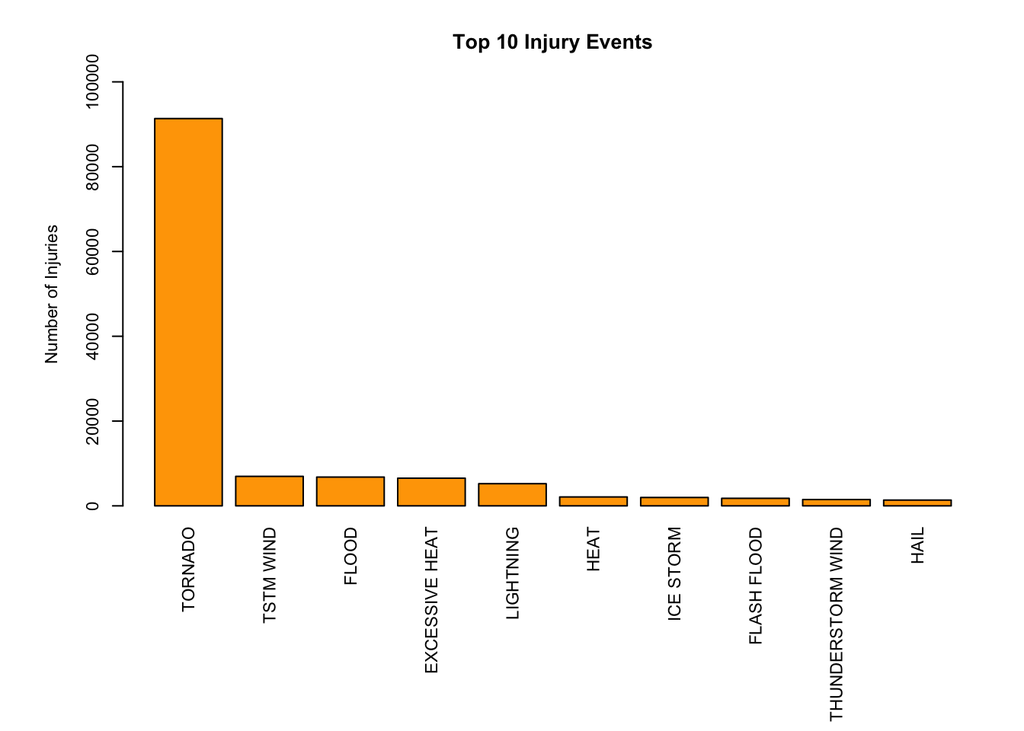

```r
options(scipen = 100)
par(mfrow = c(1,1), mar = c(11, 6, 4, 2), mgp = c(3, 1, 0), cex = 0.7)
barplot(top10InjuryEvents$INJURIES, names.arg = top10InjuryEvents$EVTYPE, las = 3,
        main = "Top 10 Injury Events",
        ylab = "Number of Injuries",
        ylim = range(0,100000),
        col = c("Orange"))
```

## Which type of events have the greatest economic consequences?

- Similar to the human health questions, since there are 985 different event types we are only going to look at the top 10 most damaging property events and top 10 most damaging crop events.

### Property Damage

```r
stormPropDmg <- aggregate(PROPDMGTOTAL ~ EVTYPE, data = storm,  FUN="sum")
dim(stormPropDmg)
```

```
## [1] 409   2
```

```r
names(stormPropDmg)
```

```
## [1] "EVTYPE"       "PROPDMGTOTAL"
```

```r
summary(stormPropDmg)
```

```
##                    EVTYPE     PROPDMGTOTAL
##     HIGH SURF ADVISORY:  1   Min.   :  0.00000
##   FLASH FLOOD         :  1   1st Qu.:  0.00002
##   TSTM WIND           :  1   Median :  0.00018
##   TSTM WIND (G45)     :  1   Mean   :  1.04700
##  ?                    :  1   3rd Qu.:  0.00486
##  APACHE COUNTY        :  1   Max.   :144.65771
##  (Other)              :403
```

```r
str(stormPropDmg)
```

```
## 'data.frame':    409 obs. of  2 variables:
##  $ EVTYPE      : Factor w/ 985 levels "   HIGH SURF ADVISORY",..: 1 3 5 6 9 15 16 17 19 21 ...
##  $ PROPDMGTOTAL: num  0.0002 0.00005 0.0081 0.000008 0.000005 ...
```

- Ordering the top 10 Weather events by property damage amounts

```r
top10PropDmgEvents <- stormPropDmg[order(-stormPropDmg$PROPDMGTOTAL), ][1:10, ]
top10PropDmgEvents
```

```
##                EVTYPE PROPDMGTOTAL
## 63              FLOOD   144.657710
## 181 HURRICANE/TYPHOON    69.305840
## 335           TORNADO    56.947381
## 283       STORM SURGE    43.323536
## 51        FLASH FLOOD    16.822674
## 105              HAIL    15.735267
## 173         HURRICANE    11.868319
## 343    TROPICAL STORM     7.703891
## 402      WINTER STORM     6.688497
## 158         HIGH WIND     5.270046
```

### Plot Property Damage

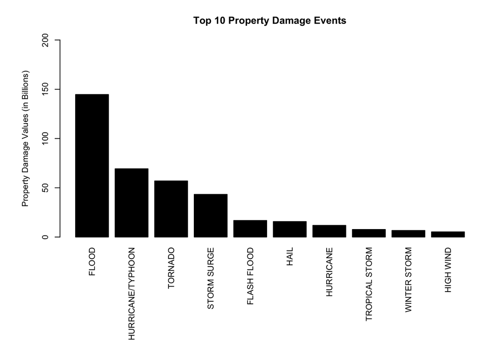

```r
par(mfrow = c(1,1), mar = c(12, 6, 4, 2), mgp = c(3, 1, 0), cex = 0.7)
barplot(top10PropDmgEvents$PROPDMGTOTAL, names.arg = top10PropDmgEvents$EVTYPE, las = 3,
        main = "Top 10 Property Damage Events",
        ylab = "Property Damage Values (in Billions)",
        ylim = range(0,200),
        col = c("Black"))
```

### Crop Damage

```r
stormCropDmg <- aggregate(CROPDMGTOTAL ~ EVTYPE, data = storm,  FUN="sum")
dim(stormCropDmg)
```

```
## [1] 162   2
```

```r
names(stormCropDmg)
```

```
## [1] "EVTYPE"       "CROPDMGTOTAL"
```

```r
summary(stormCropDmg)
```

```
##                     EVTYPE     CROPDMGTOTAL
##  AGRICULTURAL FREEZE   :  1   Min.   : 0.000000
##  ASTRONOMICAL HIGH TIDE:  1   1st Qu.: 0.000005
##  ASTRONOMICAL LOW TIDE :  1   Median : 0.000500
##  AVALANCHE             :  1   Mean   : 0.303112
##  BLIZZARD              :  1   3rd Qu.: 0.026469
##  COASTAL FLOOD         :  1   Max.   :13.972566
##  (Other)               :156
```

```r
str(stormCropDmg)
```

```
## 'data.frame':    162 obs. of  2 variables:
##  $ EVTYPE      : Factor w/ 985 levels "   HIGH SURF ADVISORY",..: 14 16 17 19 30 54 57 69 73 79 ...
##  $ CROPDMGTOTAL: num  0.0288 0 0 0 0.1121 ...
```

- Ordering the top 10 Weather events by crop damage amounts

```r
top10CropDmgEvents <- stormCropDmg[order(-stormCropDmg$CROPDMGTOTAL), ][1:10, ]
top10CropDmgEvents
```

```
##               EVTYPE CROPDMGTOTAL
## 16           DROUGHT    13.972566
## 35             FLOOD     5.661968
## 99       RIVER FLOOD     5.029459
## 86         ICE STORM     5.022113
## 53              HAIL     3.025954
## 78         HURRICANE     2.741910
## 83 HURRICANE/TYPHOON     2.607873
## 30       FLASH FLOOD     1.421317
## 26      EXTREME COLD     1.292973
## 47      FROST/FREEZE     1.094086
```

### Plot Crop Damage

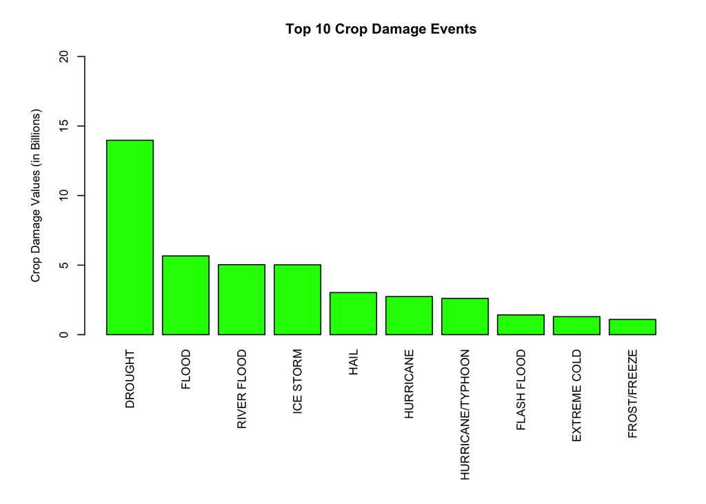

```r
par(mfrow = c(1,1), mar = c(12, 6, 4, 2), mgp = c(3, 1, 0), cex = 0.7)
barplot(top10CropDmgEvents$CROPDMGTOTAL, names.arg = top10CropDmgEvents$EVTYPE, las = 3,
        main = "Top 10 Crop Damage Events",
        ylab = "Crop Damage Values (in Billions)",
        ylim = range(0,20),
        col = c("Green"))
```